# Seurat Integration (Dataset 2)

Joey Hastings

2023-03-08

# Load Packages

```r
library(tictoc)
library(tidyverse)
library(cowplot)
library(ggExtra)
library(ggthemes)

library(splatter)
library(scater)
library(scran)
library(r.jive)
library(Seurat)
library(factoextra)
library(SLIDE)
library(RSpectra)
library(scRNAseq)
library(lme4)

library(kBET) # kBET
library(cluster) # ASW
library(lisi) # LISI
library(mclust) # ARI

theme_set(theme_few())

method_name <- "Seurat"
dataset_name <- "dataset2"
```

# Bacher T-Cell Data

## Load Data from `scRNAseq` Package

```r
BacherTCellData <- BacherTCellData()
```

```
## snapshotDate(): 2022-10-31
```

```
## see ?scRNAseq and browseVignettes('scRNAseq') for documentation
```

```
## loading from cache
```

```
## see ?scRNAseq and browseVignettes('scRNAseq') for documentation
```

```
## loading from cache
```

```r
table(BacherTCellData$batch)
```

```
##
##     1     2     3     4     5    10    11    12    13    14    15    16    17
##  2547 11585 13344 12904  3059   587  7740  9961  4623   754  1113   376   296
##    18    19
## 17915 17613
```

```r
table(BacherTCellData$batch, BacherTCellData$new_cluster_names)
```

```
##
##      Central memory Cycling Cytotoxic / Th1 Tfh-like Transitional memory
##   1             407      11             272     1399                 445
##   2            2027     261            1925     4438                2836
##   3            1517      56            1894     6874                2815
##   4            3324      24            1534     4608                3198
##   5             955      13             331      921                 736
##   10             47       1             326      130                  80
##   11           1196      11            1246     3479                1757
##   12           1620      31            1373     4625                2255
##   13            624      16             412     2243                1266
##   14            230       1              76      250                 190
##   15            239       4             143      425                 289
##   16             87       0              61      138                  87
##   17             65       0              41      107                  82
```

[output cut: 19 more lines]

Perform cell batch integration as in their tutorial.

# Seurat

### Setup

```r
bacher_metadata <- as.data.frame(colData(BacherTCellData))
bacher_seurat <- CreateSeuratObject(counts(BacherTCellData), meta.data = bacher_metadata)

#################
# Identify HVGs #
#################

# split the dataset into a list of seurat objects (one for each batch)
bacher_seurat_batch <- SplitObject(bacher_seurat, split.by = "batch")

# normalize and identify variable features for each dataset independently
bacher_seurat_batch <- lapply(X = bacher_seurat_batch, FUN = function(x) {
  x <- NormalizeData(x)
  x <- FindVariableFeatures(x, selection.method = "vst", nfeatures = 2000)
})
# select features that are repeatedly variable across datasets for integration
features <- SelectIntegrationFeatures(object.list = bacher_seurat_batch)

########################################################

batch_indices <- which(unique(bacher_seurat$batch) %in% c(14, 15)) # subset batches
bacher_seurat_batch <- bacher_seurat_batch[batch_indices]
```

### Integration

- Perform integration by finding a set of anchors from the two batches (via CCA)
- Use the anchor list to integrate the two batches

```r
anchors <- FindIntegrationAnchors(object.list = bacher_seurat_batch, anchor.features = features)
```

```
## Scaling features for provided objects
```

```
## Finding all pairwise anchors
```

```
## Running CCA
```

```
## Merging objects
```

```
## Finding neighborhoods
```

```
## Finding anchors
```

```
##  Found 3141 anchors
```

```
## Filtering anchors
```

```
##  Retained 1835 anchors
```

```r
combined <- IntegrateData(anchorset = anchors)
```

```
## Merging dataset 1 into 2
```

```
## Extracting anchors for merged samples
```

```
## Finding integration vectors
```

```
## Finding integration vector weights
```

```
## Integrating data
```

```r
GetAssay(combined, "integrated")
```

```
## Assay data with 2000 features for 1867 cells
## Top 10 variable features:
##  CCL4, IL3, CCL4L2, XCL1, XCL2, CSF2, IL10, CCL3, GZMB, IL4
```

### Integrated Analysis

- Integrated/combined data is centered/scaled
- First 30 PCs are computed/stored
- PC1-PC30 are used to perform t-SNE and UMAP dimensionality reduction
- Calculates k-nearest neighbors (`k = 20` by default) from PC1-PC30
- Identify clusters by using Shared Nearest Neighbors (SNN):
  - “First calculate k-nearest neighbors and construct the SNN graph”
  - “Then optimize the modularity function to determine clusters”

```r
# specify that we will perform downstream analysis on the corrected data note that the
# original unmodified data still resides in the 'RNA' assay
DefaultAssay(combined) <- "integrated"

# Run the standard workflow for visualization and clustering
set.seed(1)
combined <- ScaleData(combined, verbose = FALSE)
combined <- RunPCA(combined, npcs = 30, verbose = FALSE)
combined <- RunTSNE(combined, reduction = "pca", dims = 1:30)
combined <- RunUMAP(combined, reduction = "pca", dims = 1:30)
combined <- FindNeighbors(combined, reduction = "pca", dims = 1:30)
combined <- FindClusters(combined, resolution = 0.5)
```

```
## Modularity Optimizer version 1.3.0 by Ludo Waltman and Nees Jan van Eck
##
## Number of nodes: 1867
## Number of edges: 99432
##
## Running Louvain algorithm...
## Maximum modularity in 10 random starts: 0.7837
## Number of communities: 7
## Elapsed time: 0 seconds
```

```r
#
combined <- AddMetaData(combined, factor(combined$batch), col.name = "Batch")
combined <- AddMetaData(combined, factor(combined$new_cluster_names), col.name = "Cluster")
```

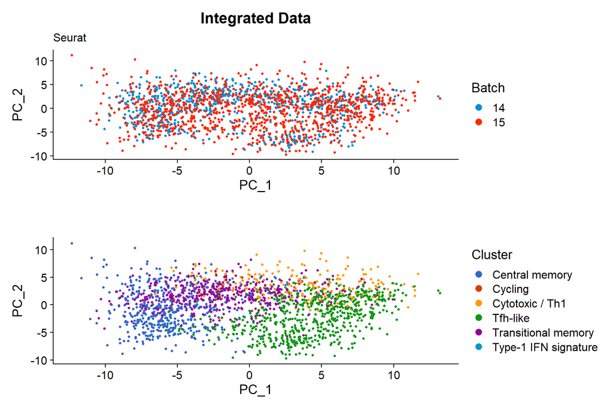

```r
title_caption <-
  labs(
    title = "Integrated Data",
    subtitle = method_name
  )

integrated_p1 <- plot_grid(
  PCAPlot(combined, group.by = "Batch") +
  scale_color_fivethirtyeight(name = "Batch") +
    title_caption,
  PCAPlot(combined, group.by = "Cluster") + scale_color_gdocs(name = "Cluster") + labs(title = ""),
  nrow=2, align = "v"
  )

integrated_p2 <- plot_grid(
  TSNEPlot(combined, group.by = "Batch") +
  scale_color_fivethirtyeight(name = "Batch") +
    title_caption,
  TSNEPlot(combined, group.by = "Cluster") + scale_color_gdocs(name = "Cluster") + labs(title = ""),
  nrow=2, align = "v"
  )

integrated_p3 <- plot_grid(
  UMAPPlot(combined, group.by = "Batch") +
    scale_color_fivethirtyeight(name = "Batch") +
    title_caption,
  UMAPPlot(combined, group.by = "Cluster") + scale_color_gdocs(name = "Cluster") + labs(title = ""),
  nrow=2, align = "v"
  )

integrated_p1 # ggsave(paste0("dataset2_j", JIVE_results$rankJ, "_a_15_14_integrated_pca.png"), integrated_p1)
```

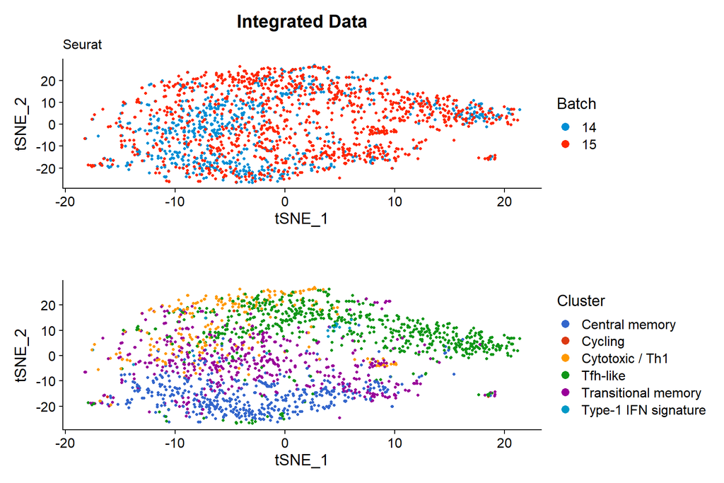

```r
integrated_p2 # ggsave(paste0("dataset2_j", JIVE_results$rankJ, "_a_15_14_integrated_tsne.png"), integrated_p2)
```

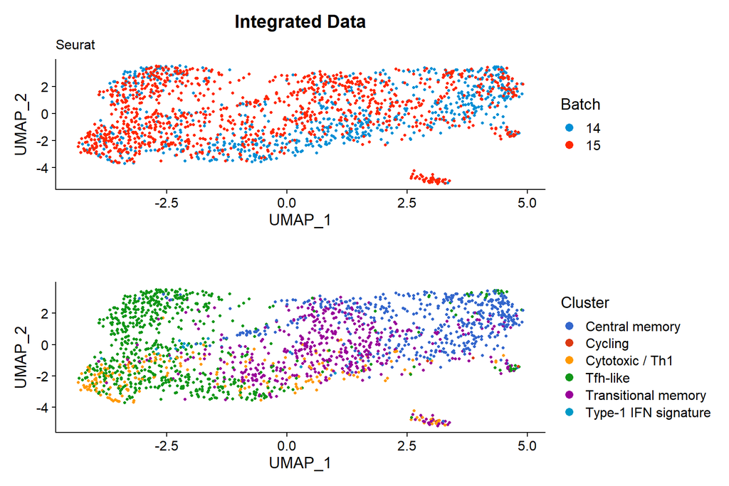

```r
integrated_p3 # ggsave(paste0("dataset2_j", JIVE_results$rankJ, "_a_15_14_integrated_umap.png"), integrated_p3)
```

```r
integrated_final <- t(combined@assays$integrated@scale.data)
batches <- combined$Batch
clusters <- combined$Cluster
```

### Calculate kBET

```r
# data: a matrix (rows: samples, columns: features (genes))
# data <- svds(integrated_final, k = 30)$u
data <- combined@reductions$pca@cell.embeddings

# batch: vector or factor with batch label of each cell
batch <- combined$Batch

sample_size <- seq(0.05, 0.25, by = 0.05)
rejection_rate <- list()

set.seed(1)
for (i in 1:length(sample_size)) {
  k <- floor(nrow(data) * sample_size[i])

  cat("\nSample Size: ", sample_size[i], ", k = ", k, "\n", sep = "")
  cat("------------------------------\n")

  batch.estimate <- kBET(data, batch, k0 = k, plot = F, do.pca = F, verbose = T)

  cat("\n------------------------------\n")

  if (class(batch.estimate) == "list") {
    rejection_rate[[i]] <- batch.estimate$summary %>%
      rownames_to_column(var = "statistic") %>%
      mutate(sample_size = sample_size[i]) %>%
      select(sample_size, statistic, kBET_rr = kBET.observed)
  }
}
```

```
##
## Sample Size: 0.05, k = 93
## ------------------------------
## finding knns...done. Time:
##    user  system elapsed
##    0.25    0.00    0.25
## Number of kBET tests is set to 187.
## No outsiders found.
## ------------------------------
##
## Sample Size: 0.1, k = 186
## ------------------------------
## finding knns...done. Time:
##    user  system elapsed
##    0.34    0.00    0.35
## Number of kBET tests is set to 187.
## There are 6 cells (0.321%) that do not appear in any neighbourhood.
## The expected frequencies for each category have been adapted.
## Cell indexes are saved to result list.
##
## ------------------------------
##
## Sample Size: 0.15, k = 280
## ------------------------------
## finding knns...done. Time:
##    user  system elapsed
##    0.44    0.00    0.44
## Number of kBET tests is set to 187.
## No outsiders found.
## ------------------------------
##
## Sample Size: 0.2, k = 373
## ------------------------------
## finding knns...done. Time:
##    user  system elapsed
##    0.53    0.00    0.54
## Number of kBET tests is set to 187.
## No outsiders found.
## ------------------------------
##
## Sample Size: 0.25, k = 466
## ------------------------------
## finding knns...done. Time:
##    user  system elapsed
##    0.66    0.00    0.66
## Number of kBET tests is set to 187.
## No outsiders found.
## ------------------------------
```

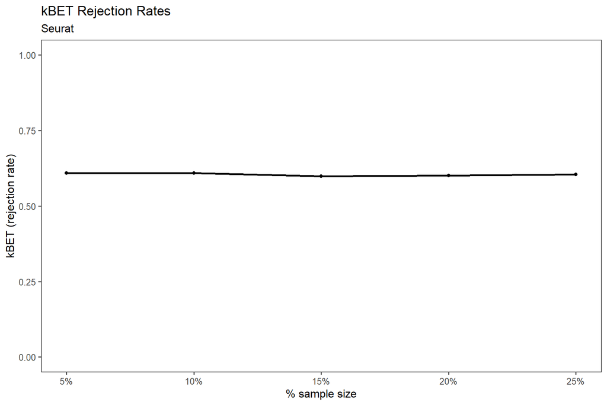

```r
all_rr <- bind_rows(rejection_rate) %>%
  mutate(method = method_name) %>%
  pivot_wider(id_cols = c(method, sample_size), names_from = statistic, values_from = kBET_rr) %>%
  select(method, sample_size, median_rr = `50%`)

all_rr %>% write_csv(file = paste0("output/", method_name, "_", dataset_name, "_kBET.csv"))

all_rr %>%
  ggplot(aes(x = sample_size, y = median_rr)) +
  geom_line(linewidth = 1) +
  geom_point() +
  scale_x_continuous(labels = scales::percent) +
  expand_limits(y = c(0, 1)) +
  labs(
    x = "% sample size",
    y = "kBET (rejection rate)",
    color = "Cell Group",
    title = "kBET Rejection Rates",
    subtitle = method_name
  )
```

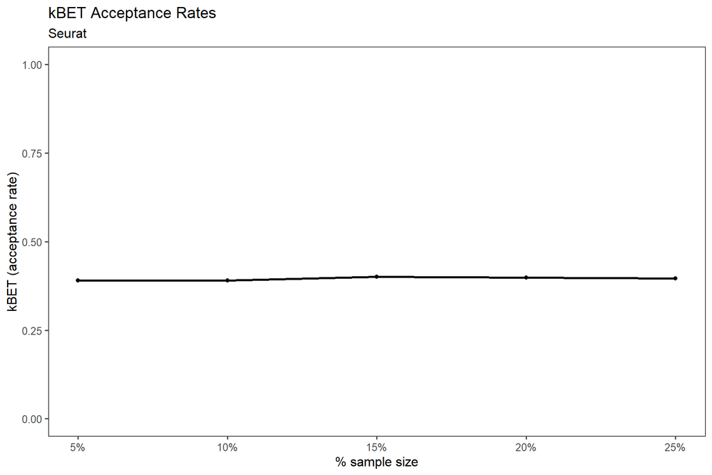

```r
all_rr %>%
  ggplot(aes(x = sample_size, y = I(1 - median_rr))) +
  geom_line(linewidth = 1) +
  geom_point() +
  scale_x_continuous(labels = scales::percent) +
  expand_limits(y = c(0, 1)) +
  labs(
    x = "% sample size",
    y = "kBET (acceptance rate)",
    color = "Cell Group",
    title = "kBET Acceptance Rates",
    subtitle = method_name
  )
```

### Calculate Average Silhouette Width

Original batch label and cell types/groups will be considered the clusters to compute $ASW_{batch}$ and $ASW_{group}$

- Compute average silhouette width (ASW) for the first 30 PCs of 80% sub-sample of joint data
  - ASW ranges between -1 and 1
  - Values **close to 1** indicate the cell is well-matched to its cluster (i.e., batch label)
  - Values **close to -1** indicate the cell is **not** well-matched to its cluster (i.e., batch label)
    - We hope to see lower values for $ASW_{batch}$ since it is indicative of well-mixed batches
    - We hope to see higher values for $ASW_{group}$ since it is indicative that distinct cell groups were preserved after batch-mixing
- Repeat `20` times
- Calculate the median ASW from the `20` runs to ensure stability of the measurement

```r
asw_repeat <- 20
npcs <- 30

asw_batch <- list()
asw_cluster <- list()
subset_prop <- 0.8 # subsample to 80% of the data
subset_size_total <- floor(length(batch) * subset_prop)

set.seed(1)
for (i in 1:asw_repeat) {
  subset_index <-
    data.frame(index = 1:length(batch) , batch = batch) %>%
    slice_sample(n = subset_size_total, replace = F)

  subset_id <- subset_index %>%
    pull(index)

  data_pc <- svds(integrated_final[subset_id, ], k = npcs)$u

  dissimilarity_matrix <- daisy(data_pc)

  asw_batch_i <- silhouette(as.integer(factor(batches[subset_id])), dissimilarity_matrix)
  asw_batch[[i]] <- as.data.frame(rbind(summary(asw_batch_i)[["si.summary"]]))

  asw_cluster_i <- silhouette(as.integer(factor(clusters[subset_id])), dissimilarity_matrix)
  asw_cluster[[i]] <- as.data.frame(rbind(summary(asw_cluster_i)[["si.summary"]]))
}

all_asw_batch <- bind_rows(asw_batch) %>%
  mutate(Cluster = "Batch")

# ASW_batch summary
summary(all_asw_batch$Mean)
```

```
##      Min.   1st Qu.    Median      Mean   3rd Qu.      Max.
## -0.005904 -0.005228 -0.004796 -0.004515 -0.003670 -0.002788
```

```r
all_asw_cluster <- bind_rows(asw_cluster) %>%
  mutate(Cluster = "Cluster")

#ASW_group summary
summary(all_asw_cluster$Mean)
```

```
##       Min.    1st Qu.     Median       Mean    3rd Qu.       Max.
## -1.088e-02 -1.426e-03  1.023e-03 -6.716e-05  2.847e-03  7.764e-03
```

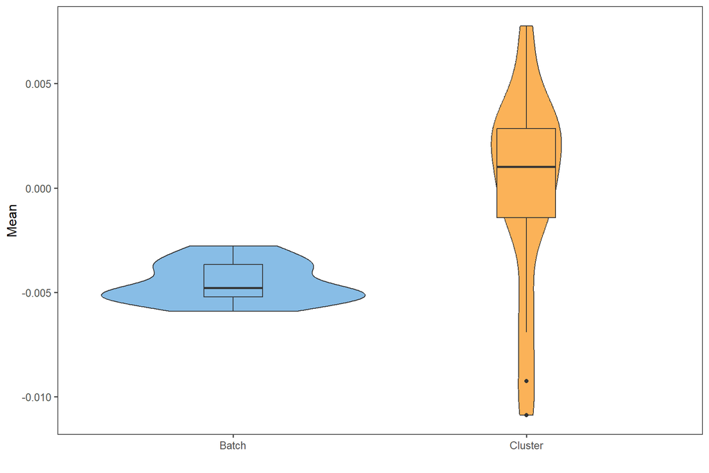

```r
all_asw <- bind_rows(all_asw_batch, all_asw_cluster)

asw_plot <- ggplot(data = all_asw, aes(x = Cluster, y = Mean, fill = Cluster)) +
  geom_violin() +
  geom_boxplot(width = 0.2) +
  labs(x = "") +
  theme(legend.position = "none") +
  scale_fill_few()

asw_plot
```

```r
all_asw %>%
  group_by(Cluster) %>%
  mutate(Method = method_name) %>%
  write_csv(file = paste0("output/", method_name, "_", dataset_name, "_ASW.csv"))
```

### Calculate LISI Scores

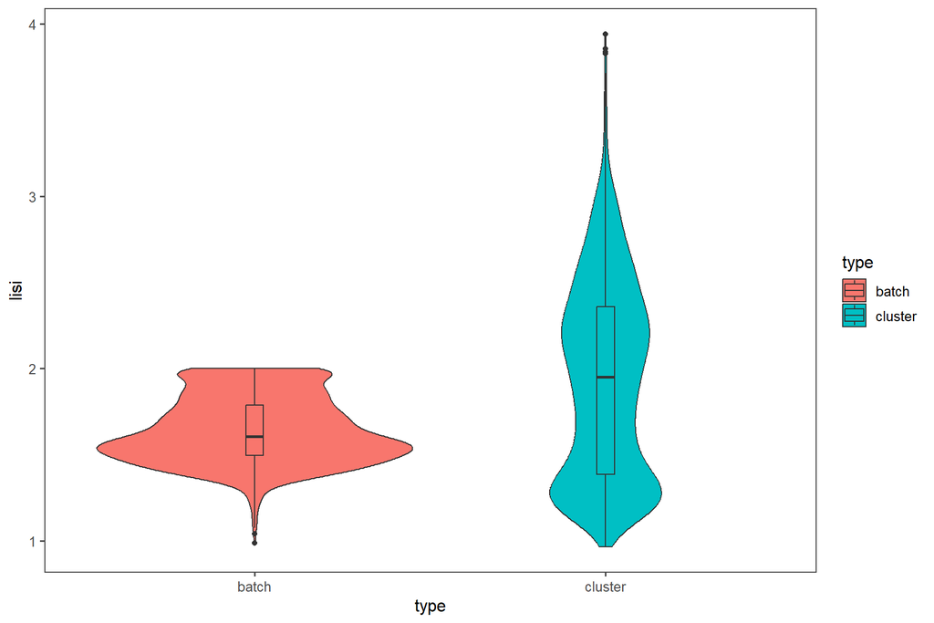

```r
# Performed for all cells

lisi <- compute_lisi(integrated_final, data.frame(batch = batches, cluster = clusters), c("batch", "cluster"), perplexity = 40) %>%
  pivot_longer(cols = c("batch", "cluster"), names_to = "type", values_to = "lisi")

# Looking for values close to the number of batches (2)
# Looking for values close to 1

ggplot(data = lisi, aes(x = type, y = lisi, fill = type)) +
  geom_violin() +
  geom_boxplot(width = 0.05)
```